# Statbank API access and interesting observations

api

statbank

dst

descriptive statistics

war

Author

Henrik Vitus Bering Laursen

Published

May 19, 2026

## 1 Purpose

I want to explore data from Statistics Denmark.

These can be accessed through their:

1. [Statistik bank tables - i.e. loggin in and making tables to export](https://www.statistikbanken.dk/statbank5a/default.asp?w=3153)
2. [Statistik bank API - allowing tailored access, getting overviews and extracting tables programmatically](https://www.dst.dk/da/Statistik/hjaelp-til-statistikbanken/api)

I have always used the table way. I did not know the API existed. Although the changelog shows evidence that it existed since 2014. There also seems to be a package, last updated in 2022, called `danstat`.

What I want to explore is:

1. What is there?
2. How it is structured?
3. What can I show that is interesting from a single table?

### 1.1 Access

The [`httr2`](https://httr2.r-lib.org/) package can be used to access the API and export. I will load that along with [`jsonlite`](https://cran.r-project.org/web/packages/jsonlite/index.html) to convert from JSON to an R object, and ofcourse [`dplyr`](https://cran.r-project.org/web/packages/dplyr/index.html) for data manipulation.

Now, I want to get an overview of what I can get my hands on via this API. It seems the following access points are available:

- https://api.statbank.dk/v1/subjects
  - Here it seems you can search within a subject and get data related to that
- https://api.statbank.dk/v1/tables
  - Overview of the different tables
- https://api.statbank.dk/v1/tableinfo
  - Metadata on the tables
- https://api.statbank.dk/v1/data
  - Here you get the actual data from the tables

Let’s look at each of these, in turn.

#### 1.1.1 Subjects

```r
resp_subjects <- request("https://api.statbank.dk/v1/subjects") |>
  req_perform()

# Parse JSON
subjects <- resp_body_json(resp_subjects, check_type = FALSE)

# Glimpse structure
glimpse(subjects)
```

```
List of 10
 $ :List of 5
  ..$ id         : chr "1"
  ..$ description: chr "Borgere"
  ..$ active     : logi TRUE
  ..$ hasSubjects: logi TRUE
  ..$ subjects   : list()
 $ :List of 5
  ..$ id         : chr "2"
  ..$ description: chr "Arbejde og indkomst"
  ..$ active     : logi TRUE
  ..$ hasSubjects: logi TRUE
  ..$ subjects   : list()
 $ :List of 5
  ..$ id         : chr "3"
  ..$ description: chr "Økonomi"
  ..$ active     : logi TRUE
  ..$ hasSubjects: logi TRUE
  ..$ subjects   : list()
 $ :List of 5
  ..$ id         : chr "4"
  ..$ description: chr "Sociale forhold"
  ..$ active     : logi TRUE
  ..$ hasSubjects: logi TRUE
  ..$ subjects   : list()
 $ :List of 5
  ..$ id         : chr "5"
  ..$ description: chr "Uddannelse og forskning"
  ..$ active     : logi TRUE
  ..$ hasSubjects: logi TRUE
  ..$ subjects   : list()
 $ :List of 5
  ..$ id         : chr "6"
  ..$ description: chr "Erhvervsliv"
  ..$ active     : logi TRUE
  ..$ hasSubjects: logi TRUE
  ..$ subjects   : list()
 $ :List of 5
  ..$ id         : chr "7"
  ..$ description: chr "Transport"
  ..$ active     : logi TRUE
  ..$ hasSubjects: logi TRUE
  ..$ subjects   : list()
 $ :List of 5
  ..$ id         : chr "8"
  ..$ description: chr "Kultur og fritid"
  ..$ active     : logi TRUE
  ..$ hasSubjects: logi TRUE
  ..$ subjects   : list()
 $ :List of 5
  ..$ id         : chr "9"
  ..$ description: chr "Miljø og energi"
  ..$ active     : logi TRUE
  ..$ hasSubjects: logi TRUE
  ..$ subjects   : list()
 $ :List of 5
  ..$ id         : chr "19"
  ..$ description: chr "Om Danmarks Statistik"
  ..$ active     : logi TRUE
  ..$ hasSubjects: logi TRUE
  ..$ subjects   : list()
```

Ok so there are 10 different subjects, one about Statistics Denmark.

```r
# Get names
sapply(subjects, `[[`, "description")
```

```
 [1] "Borgere"                 "Arbejde og indkomst"
 [3] "Økonomi"                 "Sociale forhold"
 [5] "Uddannelse og forskning" "Erhvervsliv"
 [7] "Transport"               "Kultur og fritid"
 [9] "Miljø og energi"         "Om Danmarks Statistik"
```

The `purr` package provides a more human-readable way of extracting it. May as well add the id.

```r
tibble(
  id = map_chr(subjects, "id"),
  description = map_chr(subjects, "description")
)
```

```
# A tibble: 10 × 2
   id    description
   <chr> <chr>
 1 1     Borgere
 2 2     Arbejde og indkomst
 3 3     Økonomi
 4 4     Sociale forhold
 5 5     Uddannelse og forskning
 6 6     Erhvervsliv
 7 7     Transport
 8 8     Kultur og fritid
 9 9     Miljø og energi
10 19    Om Danmarks Statistik
```

So, instead of: “apply the `[[` extractor on this data frame, looking for the string ‘description’, and simplify into a vector”, it’s more like: “make a dataframe that contains the contents on this map (the dataframe), specifically the characters in the ‘id’ column and ‘description’ column”.

Who knows, for some the latter might be less simple, but at least it is more visual.

#### 1.1.2 Tables

How many tables does the tables api link have?

```r
# Request table overview
resp_tables <- request("https://api.statbank.dk/v1/tables") |>
  req_body_json(list(lang = "en")) |>
  req_perform()

# Parse JSON
dst_tables <- resp_body_json(resp_tables, check_type = FALSE)

# Convert to dataframe and glimpse structure
dst_tables_df <- bind_rows(dst_tables)
glimpse(dst_tables_df)
```

```
Rows: 9,136
Columns: 8
$ id           <chr> "FOLK1A", "FOLK1A", "FOLK1A", "FOLK1A", "FOLK1A", "FOLK1A…
$ text         <chr> "Population at the first day of the quarter", "Population…
$ unit         <chr> "Number", "Number", "Number", "Number", "Number", "Number…
$ updated      <chr> "2026-05-11T08:00:00", "2026-05-11T08:00:00", "2026-05-11…
$ firstPeriod  <chr> "2008Q1", "2008Q1", "2008Q1", "2008Q1", "2008Q1", "2021M1…
$ latestPeriod <chr> "2026Q2", "2026Q2", "2026Q2", "2026Q2", "2026Q2", "2026M0…
$ active       <lgl> TRUE, TRUE, TRUE, TRUE, TRUE, TRUE, TRUE, TRUE, TRUE, TRU…
$ variables    <list> "region", "sex", "age", "marital status", "time", "regio…
```

```r
test <- tibble(unlist(dst_tables_df[8]))
print(test, n = 15)
```

```
# A tibble: 9,136 × 1
   `unlist(dst_tables_df[8])`
   <chr>
 1 region
 2 sex
 3 age
 4 marital status
 5 time
 6 region
 7 sex
 8 age
 9 time
10 sex
11 age
12 marital status
13 time
14 sex
15 age
# ℹ 9,121 more rows
```

```r
test2 <- dst_tables_df |> slice(1) |> select(variables) |> unlist()
```

It seems that each row that seems like a duplicate for e.g. the table with the id `FOLK1A`, is duplicated in all variables except for the character variable in the list in the `variables` column.

That seems weird, to keep only one character hidden in a list in the `variables` colum. But since it has probably been possible to access this in this way since 2014 there must be a purpose to it.

Let’s see how many unique tables there are.

```r
distinct(dst_tables_df, id) |> count()
```

```
# A tibble: 1 × 1
      n
  <int>
1  2276
```

**For now, I want to look at FOLK1C.**

#### 1.1.3 Tableinfo

What does [`tableinfo`](https://api.statbank.dk/v1/tableinfo) actually tell us?

```r
# Request
resp_meta <- request("https://api.statbank.dk/v1/tableinfo") |>
  req_body_json(list(table = "folk1c", lang = "en")) |> # always need to pick a specific table
  req_perform()

# Parse JSON
meta <- resp_body_json(resp_meta, check_type = FALSE)

# Remove the contact part of the list - seems inappropriate to put this info here.
meta$contacts <- NULL

# Convert to dataframe and glimpse structure
glimpse(meta)
```

```
List of 10
 $ id                 : chr "FOLK1C"
 $ text               : chr "Population at the first day of the quarter"
 $ description        : chr "Population at the first day of the quarter by region, sex, age, ancestry, country of origin and time"
 $ unit               : chr "Number"
 $ suppressedDataValue: chr "0"
 $ updated            : chr "2026-05-11T08:00:00"
 $ active             : logi TRUE
 $ documentation      :List of 2
  ..$ id : chr "4a12721d-a8b0-4bde-82d7-1d1c6f319de3"
  ..$ url: chr "https://www.dst.dk/documentationofstatistics/4a12721d-a8b0-4bde-82d7-1d1c6f319de3"
 $ footnote           : NULL
 $ variables          :List of 6
  ..$ :List of 6
  .. ..$ id         : chr "OMRÅDE"
  .. ..$ text       : chr "region"
  .. ..$ elimination: logi TRUE
  .. ..$ time       : logi FALSE
  .. ..$ map        : chr "denmark_municipality_07"
  .. ..$ values     :List of 105
  ..$ :List of 5
  .. ..$ id         : chr "KØN"
  .. ..$ text       : chr "sex"
  .. ..$ elimination: logi TRUE
  .. ..$ time       : logi FALSE
  .. ..$ values     :List of 3
  ..$ :List of 5
  .. ..$ id         : chr "ALDER"
  .. ..$ text       : chr "age"
  .. ..$ elimination: logi TRUE
  .. ..$ time       : logi FALSE
  .. ..$ values     :List of 22
  ..$ :List of 5
  .. ..$ id         : chr "HERKOMST"
  .. ..$ text       : chr "ancestry"
  .. ..$ elimination: logi TRUE
  .. ..$ time       : logi FALSE
  .. ..$ values     :List of 4
  ..$ :List of 6
  .. ..$ id         : chr "IELAND"
  .. ..$ text       : chr "country of origin"
  .. ..$ elimination: logi TRUE
  .. ..$ time       : logi FALSE
  .. ..$ map        : chr "Verden_dk2"
  .. ..$ values     :List of 242
  ..$ :List of 5
  .. ..$ id         : chr "Tid"
  .. ..$ text       : chr "time"
  .. ..$ elimination: logi FALSE
  .. ..$ time       : logi TRUE
  .. ..$ values     :List of 74
```

It is a list of 10 lists, where the last list is a list of variables, each containing lists.

What is inside that variable list? Since it’s lists upon lists, `map_dfr` can help us go through each element in the `variables` list and make dataframes/tibbles.

```r
# Pick one thing to look at
values_by_variable <- map(meta$variables, function(var) {
  map_dfr(var$values, function(val) {
    tibble(
      value_id = val$id,
      value_text = val$text
    )
  })
})

names(values_by_variable) <- map_chr(meta$variables, "id")
values_by_variable
```

```
$OMRÅDE
# A tibble: 105 × 2
   value_id value_text
   <chr>    <chr>
 1 000      All Denmark
 2 084      Region Hovedstaden
 3 101      Copenhagen
 4 147      Frederiksberg
 5 155      Dragør
 6 185      Tårnby
 7 165      Albertslund
 8 151      Ballerup
 9 153      Brøndby
10 157      Gentofte
# ℹ 95 more rows

$KØN
# A tibble: 3 × 2
  value_id value_text
  <chr>    <chr>
1 TOT      Total
2 1        Men
3 2        Women

$ALDER
# A tibble: 22 × 2
   value_id value_text
   <chr>    <chr>
 1 IALT     Age, total
 2 0-4      0-4 years
 3 5-9      5-9 years
 4 10-14    10-14 years
 5 15-19    15-19 years
 6 20-24    20-24 years
 7 25-29    25-29 years
 8 30-34    30-34 years
 9 35-39    35-39 years
10 40-44    40-44 years
# ℹ 12 more rows

```

[output cut: 25 more lines]

```
$Tid
# A tibble: 74 × 2
   value_id value_text
   <chr>    <chr>
 1 2008K1   2008Q1
 2 2008K2   2008Q2
 3 2008K3   2008Q3
 4 2008K4   2008Q4
 5 2009K1   2009Q1
 6 2009K2   2009Q2
 7 2009K3   2009Q3
 8 2009K4   2009Q4
 9 2010K1   2010Q1
10 2010K2   2010Q2
# ℹ 64 more rows
```

That’s quite neat to get information about tables like that. Now for what the data url has in store.

#### 1.1.4 Data

What data can be found in the [`data access`](https://api.statbank.dk/v1/data) url?

Following the list logic, I will attempt to make a request that matches how it is structured in the output that R makes from JSON. That is, lists upon lists.

I thought that I could just use `format = "JSON"`, but after fiddling with [the console](https://api.statbank.dk/console#data) for a bit, I learned that it accepts “JSONSTAT”.

Additionally, I learned how to interact with it by:

- Choosing a table
- Identifying its variables and their values
- Put the variables and their values that I want in the `variables` part of the `req_body_json()` function
- Get the output I want

Variables are accessed through a list, then I have to make a list for each variable that I want to include, and a list with a regular expression text string the API can understand to get the values from that variable.

```r
# Request
resp_data <- request("https://api.statbank.dk/v1/data") |>
  req_body_json(list(
    table = "folk1c",
    format = "JSONSTAT",
    variables = list(
      list(
        code = "IELAND",
        values = list("0000")
      ),
      list(
        code = "Tid",
        values = list("*K*")
      )
    )
  )) |> # always need to pick a specific table
  req_perform()

# Parse JSON
data <- resp_body_json(resp_data, check_type = FALSE)
# Convert to dataframe and glimpse structure
glimpse(data)
```

```
List of 1
 $ dataset:List of 6
  ..$ dimension:List of 6
  .. ..$ IELAND      :List of 2
  .. ..$ ContentsCode:List of 2
  .. ..$ Tid         :List of 2
  .. ..$ id          :List of 3
  .. ..$ size        :List of 3
  .. ..$ role        :List of 3
  ..$ label    : chr "Befolkningen den 1. i kvartalet efter oprindelsesland, Indhold og tid"
  ..$ source   : chr "Danmarks Statistik"
  ..$ updated  : chr "2026-05-11T06:00:00Z"
  ..$ value    :List of 74
  .. ..$ : int 5475791
  .. ..$ : int 5482266
  .. ..$ : int 5489022
  .. ..$ : int 5505995
  .. ..$ : int 5511451
  .. ..$ : int 5515287
  .. ..$ : int 5519441
  .. ..$ : int 5532531
  .. ..$ : int 5534738
  .. ..$ : int 5540241
  .. ..$ : int 5543819
  .. ..$ : int 5557709
  .. ..$ : int 5560628
  .. ..$ : int 5564219
  .. ..$ : int 5566856
  .. ..$ : int 5579204
  .. ..$ : int 5580516
  .. ..$ : int 5584758
  .. ..$ : int 5587085
  .. ..$ : int 5599665
  .. ..$ : int 5602628
  .. ..$ : int 5605836
  .. ..$ : int 5608784
  .. ..$ : int 5623501
  .. ..$ : int 5627235
  .. ..$ : int 5634437
  .. ..$ : int 5639719
```

[output cut: 34 more lines]

```
  .. ..$ : int 5941388
  .. ..$ : int 5944145
  .. ..$ : int 5959464
  .. ..$ : int 5961249
  .. ..$ : int 5967824
  .. ..$ : int 5972420
  .. ..$ : int 5989985
  .. ..$ : int 5992734
  .. ..$ : int 5999677
  .. ..$ : int 6002420
  .. ..$ : int 6019866
  .. ..$ : int 6025603
  .. ..$ : int 6031247
  ..$ extension:List of 1
  .. ..$ px:List of 3
```

Maybe I should just get CSV format. CSV can be heavier than JSON, but that wont matter much for these data sizes. I would still have to do the whole thing from above but at least I wouldn’t have to deal with all the metadata. `readr` good for reading csv’s.

```r
# Request
resp_data <- request("https://api.statbank.dk/v1/data") |>
  req_body_json(list(
    table = "folk1c",
    format = "CSV",
    variables = list(
      list(
        code = "IELAND",
        values = list("0000")
      ),
      list(
        code = "Tid",
        values = list("*K*")
      )
    )
  )) |> # always need to pick a specific table
  req_perform()

# Parse JSON
data <- resp_body_string(resp_data) |>
  read_csv() |>
  tidyr::separate(
    col = `IELAND;TID;INDHOLD`,
    into = c("IELAND", "TID", "INDHOLD"),
    sep = ";"
  )
# Convert to dataframe and glimpse structure
glimpse(data)
```

```
Rows: 74
Columns: 3
$ IELAND  <chr> "I alt", "I alt", "I alt", "I alt", "I alt", "I alt", "I alt",…
$ TID     <chr> "2008K1", "2008K2", "2008K3", "2008K4", "2009K1", "2009K2", "2…
$ INDHOLD <chr> "5475791", "5482266", "5489022", "5505995", "5511451", "551528…
```

Great! I think I have enough to know what to do to get a basic data extraction from the DST API and make a simple graph based on it.

### 1.2 Brief analysis

What I want to now is to:

- Take the FOLK1C table
- Fokus on the amount of people in Denmark of different countries (`IELAND`) [^1]
  - Germany
  - France
  - USA
  - Russia
  - Ukraine
- Create a line diagram for as long a time period as can fit neatly on a table
- Look at the changes in the population from those countries over time

**For that**, first I have to get the country codes from the meta data, then make a big request for the data, and then make the analysis and do the analysis.

#### 1.2.1 Meta for the table

Just in case I want to make changes to the variables, I make a function to quickly extract the information I want from the Meta data.

```r
get_values_by_id <- function(meta, variable_id) {
  variable_ids <- map_chr(meta$variables, "id")
  variable <- meta$variables[[which(variable_ids == variable_id)]]

  tibble(
    variable_id = variable$id,
    variable_text = variable$text,
    value_id = map_chr(variable$values, "id"),
    value_text = map_chr(variable$values, "text")
  )
}
```

Then I can simply use `stringr` to get the right countries. Maybe I should have just used the `package::function()` thing before, and not load so many different packages for just one or two functions each. Nope. I will probably use it a lot since a lot of columns are characters.

```
# A tibble: 5 × 4
  variable_id variable_text     value_id value_text
  <chr>       <chr>             <chr>    <chr>
1 IELAND      country of origin 5130     France
2 IELAND      country of origin 5700     Russia
3 IELAND      country of origin 5180     Germany
4 IELAND      country of origin 5704     Ukraine
5 IELAND      country of origin 5390     USA
```

#### 1.2.2 Requesting the table

This will be a big chunk, because of the lists within lists structure in the request.

```r
resp <- request("https://api.statbank.dk/v1/data") |>
  req_body_json(
    list(
      table = "folk1c",
      format = "CSV",
      lang = "en",
      variables = list(
        list(
          code = "OMRÅDE",
          values = list("000") # All Denmark
        ),
        list(
          code = "KØN",
          values = list("*") # Men, Women
        ),
        list(
          code = "ALDER",
          values = list("*") # All age categories, including total
        ),
        list(
          code = "IELAND",
          values = list(
            "5700", # Russia
            "5704", # Ukraine
            "5390", # United states
            "5180", # Germany
            "5130" # France
          )
        ),
        list(
          code = "Tid",
          values = list("*")
        )
      )
    ),
    auto_unbox = TRUE
  ) |>
  req_perform()

# extract the CSV
folk1c_raw <- resp_body_string(resp) |> read_csv()
# get column names for separation
folk1c_raw_col <- names(folk1c_raw)

# Clean and print
folk1c <- folk1c_raw |>
  tidyr::separate(
    col = folk1c_raw_col,
    into = c("OMRÅDE", "KØN", "ALDER", "IELAND", "TID", "INDHOLD"),
    sep = ";"
  ) |>
  janitor::clean_names() |>
  select(-omrade) |>
  rename(
    value = indhold,
    sex = kon,
    age = alder,
    time = tid)

folk1c
```

```
# A tibble: 24,420 × 5
   sex   age        ieland time   value
   <chr> <chr>      <chr>  <chr>  <chr>
 1 Total Age, total Russia 2008Q1 4383
 2 Total Age, total Russia 2008Q2 4472
 3 Total Age, total Russia 2008Q3 4542
 4 Total Age, total Russia 2008Q4 4677
 5 Total Age, total Russia 2009Q1 4753
 6 Total Age, total Russia 2009Q2 4864
 7 Total Age, total Russia 2009Q3 4882
 8 Total Age, total Russia 2009Q4 4964
 9 Total Age, total Russia 2010Q1 5039
10 Total Age, total Russia 2010Q2 5134
# ℹ 24,410 more rows
```

That was a biggie. But extremely satisfying to have done it - without AI help I might add. Also, no need for the “OMRÅDE” variable as its only value is “All Denmark”.

#### 1.2.3 Graph and Analysis

Now for the graph.

To specify the graph further, I want to just, or at least first, look at:

- Changes in population count for the different countries
- All ages
- From earliest time to latest

But first, the time variable needs to be reformatted. It seems to be formatted such that it can be turned into an ordered factor. yyyyq1..2..3..4.

But may as well attempt to make another variable that corresponds to the first day in the month of each quarter.

```r
# Turn into ordered factor
folk1c$timef <- as.ordered(folk1c$time)

# Make a separate numeric time variable
folk1c <- folk1c |>
  mutate(
    year = as.integer(str_extract(time, "\\d{4}")),
    quarter = as.integer(str_extract(time, "(?<=Q)\\d")),
    year_quarter_num = year + (quarter - 1) / 4,
    time_smoq = lubridate::ymd(paste0(year, "-", (quarter - 1) * 3 + 1, "-01")) # smoq = start month of quarter
  )
```

And then a plot to test it out.

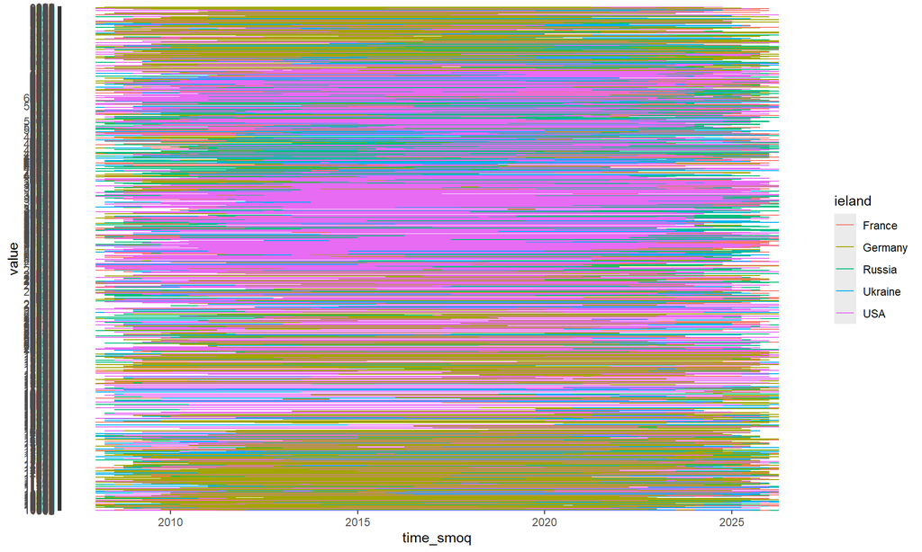

```r
# plot attempt 1
plot1 <- ggplot(folk1c, aes(time_smoq, value, color = ieland)) +
  geom_line()
plot1
```

Well.. That’s not what I expected. And maybe that is because `value` is still a character.. And age category and sex should be factors or else I might get issues in the future.

```r
folk1c <- folk1c |>
  mutate(
    value = as.integer(value),
    age_order = case_when(
      str_detect(age, "total") ~ -1, # so total is before the other categories
      TRUE ~ as.numeric(str_extract(age, "\\d+"))
    ),
    age = forcats::fct_reorder(age, age_order, .fun = min, .na_rm = TRUE))
levels(folk1c$age)
```

```
 [1] "Age, total"         "0-4 years"          "5-9 years"
 [4] "10-14 years"        "15-19 years"        "20-24 years"
 [7] "25-29 years"        "30-34 years"        "35-39 years"
[10] "40-44 years"        "45-49 years"        "50-54 years"
[13] "55-59 years"        "60-64 years"        "65-69 years"
[16] "70-74 years"        "75-79 years"        "80-84 years"
[19] "85-89 years"        "90-94 years"        "95-99 years"
[22] "100 years and over"
```

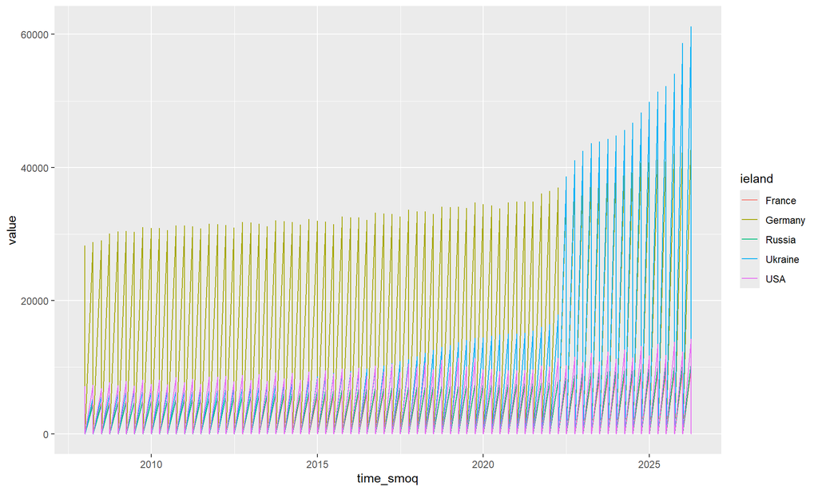

```r
# plot attempt 2
plot2 <- ggplot(folk1c, aes(time_smoq, value, color = ieland)) +
  geom_line()
plot2
```

Still not what I expected. Since I am completely not thinking this through and forgetting about all the different variables the dataset has that I am not using.

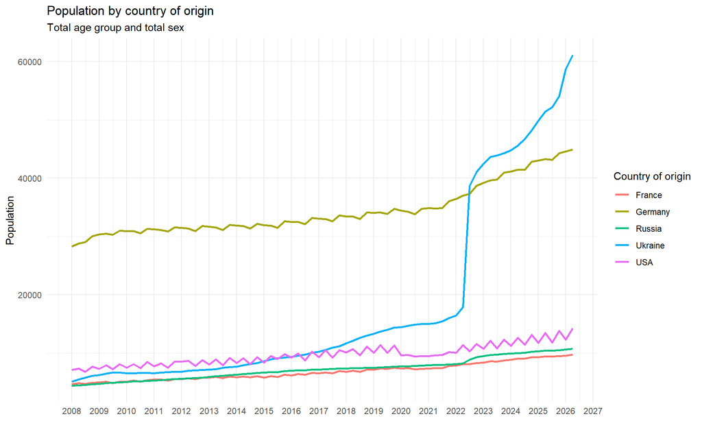

```r
folk1c_total <- folk1c |>
  filter(age == "Age, total", sex == "Total")

ggplot(folk1c_total, aes(time_smoq, value, color = ieland)) +
  geom_line(linewidth = 1) +
  labs(
    title = "Population by country of origin",
    subtitle = "Total age group and total sex",
    x = NULL,
    y = "Population",
    color = "Country of origin"
  ) +
    scale_x_date(
    date_breaks = "1 year",
    date_labels = "%Y"
  ) +
  theme_minimal()
```

This could also be perfect for a `facet_grid()`. And since there are so many age categories, probably divide them into two.

There are 21 different age categories, so could start with filtering the first 11, and then the next 10. And split up the sexes.

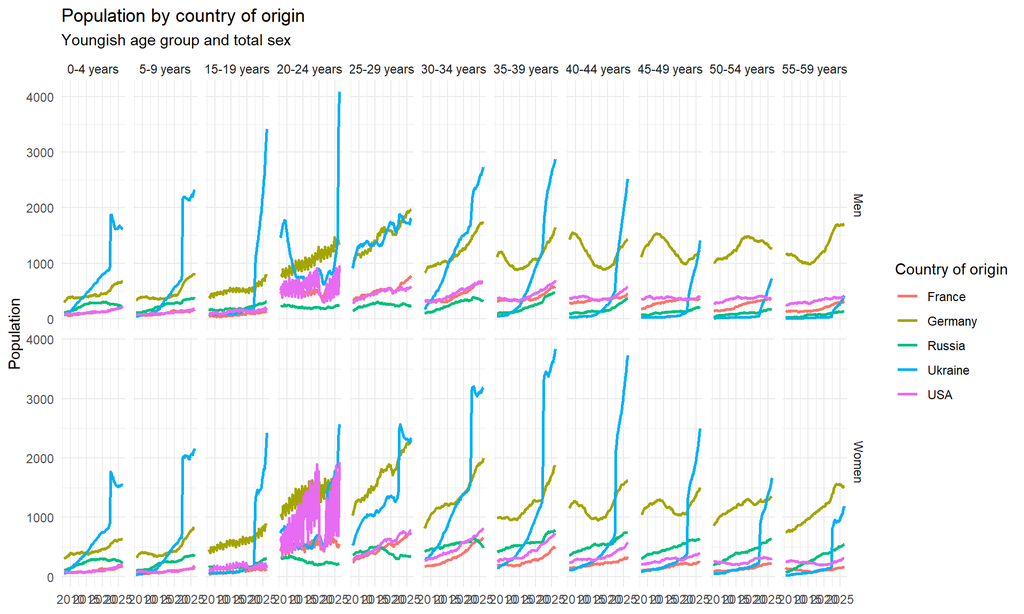

```r
# filter age groups
folk1c_young <- folk1c |>
  filter(
    str_detect(age, "^0|^5|^10$|^15|^20|^25|^30|^35|^40|^45|^50"),
    sex != "Total"
    )
folk1c_old <- folk1c |>
  filter(
    str_detect(age, "^55|^60|^65|^70|^75|^80|^90|^95|^100"),
    sex != "Total"
    )

# facet_wrap_young
ggplot(folk1c_young, aes(time_smoq, value, color = ieland)) +
  geom_line(linewidth = 1) +
  facet_grid(sex ~ age, scales = "free_y") +
  labs(
    title = "Population by country of origin",
    subtitle = "Youngish age group and total sex",
    x = NULL,
    y = "Population",
    color = "Country of origin"
  ) +
  theme_minimal()
```

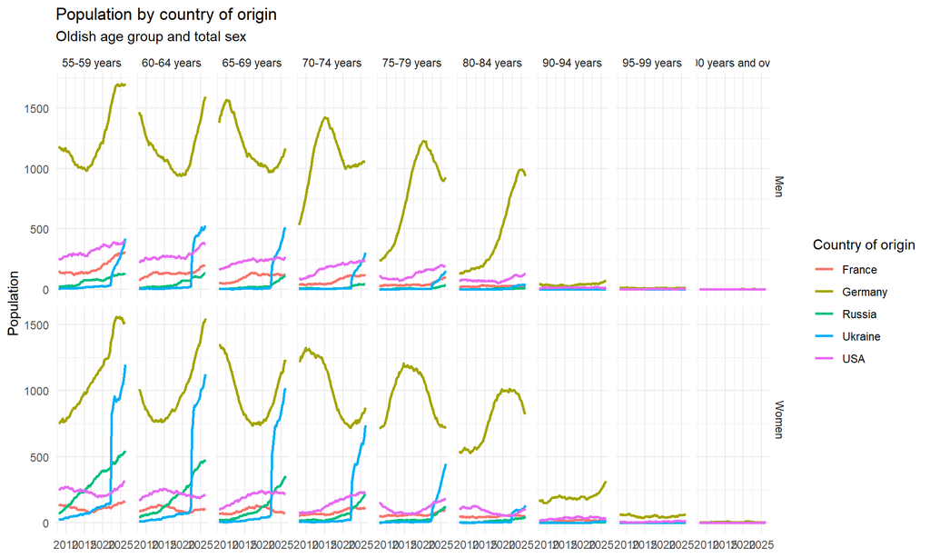

```r
# facet_wrap_old

ggplot(folk1c_old, aes(time_smoq, value, color = ieland)) +
  geom_line(linewidth = 1) +
  facet_grid(sex ~ age, scales = "free_y") +
  labs(
    title = "Population by country of origin",
    subtitle = "Oldish age group and total sex",
    x = NULL,
    y = "Population",
    color = "Country of origin"
  )  +
  theme_minimal()
```

We **COULD** also separate age groups into three categories, so the plot isnt so crowded. Let’s do that, with a different approach: keeping the folk1c, but make a variable that can be used to filter the age groups within the dataset.

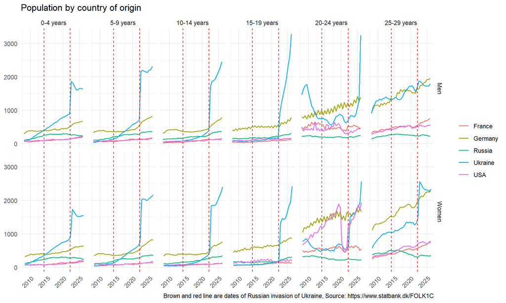

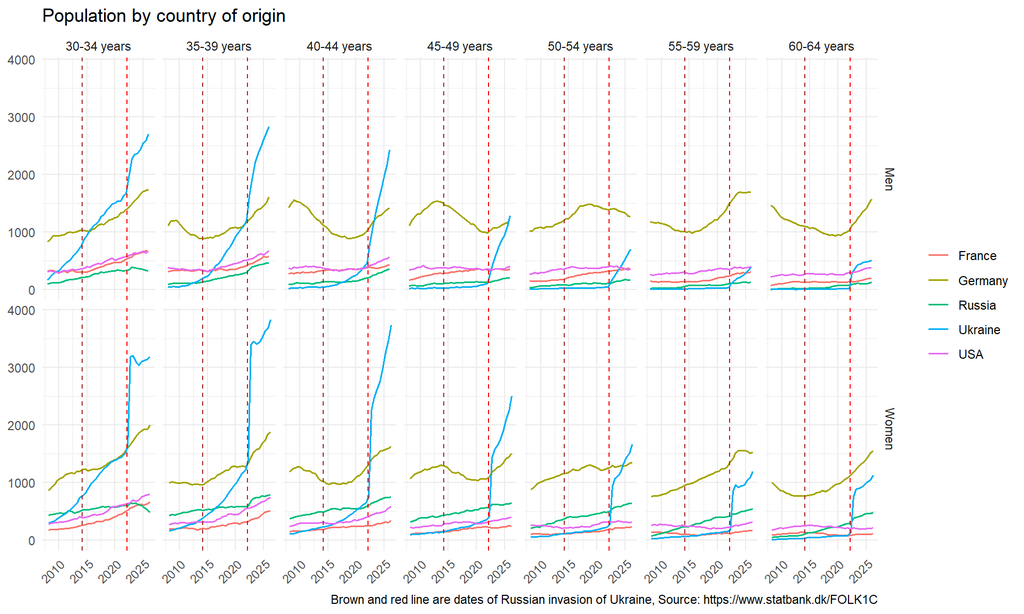

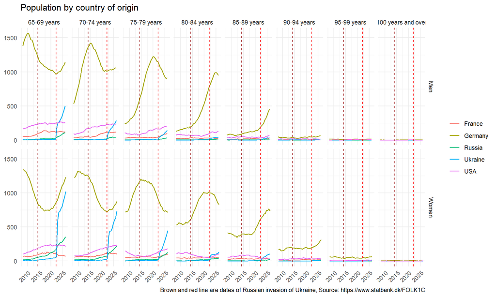

Wonderful. You may have noticed that the countries I chose were not at random. I chose Germany, France, and USA as a sort of baseline comparator. Countries not directly involved in the “special operations” that Russia has carried out towards Ukraine.

A lot can be interpreted from the graphs.

I will limit my interpretation to the plot also used in the thumbnail, for the age groups 0 to 29 years. I will assume that the increase in population is due to migration.

**Interpretation of most trends at-a-glance**:

- There is an obvious increase in migration of Ukranians for most age groups and both sexes around the 2022 Russia-Ukraine war
- There is a clear difference between the sexes
  - More boys/men migrate to Denmark among the younger age categories
  - More girls/women migrate to Denmark among the 25-29 age category
  - In the 20-29 age range, more women migrate “right” after the war, while men stay, except for the 20-24 age range which has the same incredibly large spike near 2026 as the 15-19 year range
- The Russian migration to Denmark is steady and low, but is either consistently increasing (5-19 range), or increasing and then decreasing at the start of 2022 (0-4), or decreasing and then increasing a little around 2022 (20-29)
- The German, French, and USA migration is also affected by the 2022 Russia-Ukraine war
  - Mainly marked by an a slight increasing trend
  - A very strange signal for the women aged 20-24, where the migration drops significantly before 2021, and picks up after 2022.

**My overall interpretation**:

- Migration from Ukraine increases to Denmark during the Russia-Ukraine war
- The young ukranian men at the age of conscription or military service migrate less to Denmark, around the time they are needed, except for the 15-24 year olds towards 2026
- More ukranian boys of non-military-service age migrate to Denmark than girls

This is probably due to families wanting to send both their sons and daughters away from the possibility of serving in a war. Because they want to protect their loved ones, or because they do not believe the war can be won? Because they are not needed due to drones being the differentiator in battle at the moment? It would surprise me that more boys migrate, except for the fact that they are more likely to be recruited to the military. But if Ukraine is lacking boys to fight - will they recruit more girls?

Who knows - probably a military analyst.

For now, I will just leave it at this, and find more interesting data from Statistics Denmark in the future.

### 1.3 Refactor

```
# Packages ---------------------------------------------------------------
library(httr2)
library(readr)
library(dplyr)
library(stringr)
library(lubridate)
library(forcats)
library(ggplot2)
library(janitor)

# Get FOLK1C from StatBank API ------------------------------------------
resp <- request("https://api.statbank.dk/v1/data") |>
  req_body_json(
    list(
      table = "FOLK1C",
      format = "CSV",
      lang = "en",
      timeOrder = "Ascending",
      variables = list(
        list(code = "OMRÅDE", values = list("000")), # All Denmark
        list(code = "KØN", values = list("*")),      # Total, Men, Women
        list(code = "ALDER", values = list("*")),    # All age groups
        list(
          code = "IELAND",
          values = list(
            "5700", # Russia
            "5704", # Ukraine
            "5390", # United States
            "5180", # Germany
            "5130"  # France
          )
        ),
        list(code = "Tid", values = list(">=2008K1<=2026K2"))
      )
    ),
    auto_unbox = TRUE
  ) |>
  req_perform()

# Parse and clean --------------------------------------------------------
```

[output cut: 55 more lines]

```
      caption = "Source: Statistics Denmark, StatBank table FOLK1C. Dashed lines mark Russia's 2014 and 2022 invasions of Ukraine.",
      x = NULL,
      y = "Population",
      color = "Country of origin"
    ) +
    theme_minimal() +
    theme(
      axis.text.x = element_text(angle = 45, hjust = 1)
    )
}

# Example plots ----------------------------------------------------------
plot_folk1c(folk1c, age_category = "Young")
plot_folk1c(folk1c, age_category = "Adult")
plot_folk1c(folk1c, age_category = "Older")
```

## Footnotes

[^1]: IE probably stands for immigration/emmigration and land is ofcourse country